# Computational Cognition Project Submission

Hanna Algedri, Luna Döring, Kaya Gärtner

Dataset: Lifestyle and Wellbeing: https://www.kaggle.com/ydalat/lifestyle-and-wellbeing-data

```python
import os
import numpy as np
import pandas as pd
import seaborn as sns
import statsmodels.api as sm
import matplotlib.pyplot as plt
import matplotlib.patches as mpatches
```

```python
df = pd.read_csv('https://raw.githubusercontent.com/rolli136/computationalCognition/main/Wellbeing_and_lifestyle_data_Kaggle.csv')
```

```python
df.head()
```

|  | Timestamp | FRUITS_VEGGIES | DAILY_STRESS | PLACES_VISITED | CORE_CIRCLE | SUPPORTING_OTHERS | SOCIAL_NETWORK | ACHIEVEMENT | DONATION | BMI_RANGE | TODO_COMPLETED | FLOW | DAILY_STEPS | LIVE_VISION | SLEEP_HOURS | LOST_VACATION | DAILY_SHOUTING | SUFFICIENT_INCOME | PERSONAL_AWARDS | TIME_FOR_PASSION | WEEKLY_MEDITATION | AGE | GENDER | WORK_LIFE_BALANCE_SCORE |
| --- | --- | --- | --- | --- | --- | --- | --- | --- | --- | --- | --- | --- | --- | --- | --- | --- | --- | --- | --- | --- | --- | --- | --- | --- |
| 0 | 7/7/15 | 3 | 2 | 2 | 5 | 0 | 5 | 2 | 0 | 1 | 6 | 4 | 5 | 0 | 7 | 5 | 5 | 1 | 4 | 0 | 5 | 36 to 50 | Female | 609.5 |
| 1 | 7/7/15 | 2 | 3 | 4 | 3 | 8 | 10 | 5 | 2 | 2 | 5 | 2 | 5 | 5 | 8 | 2 | 2 | 2 | 3 | 2 | 6 | 36 to 50 | Female | 655.6 |
| 2 | 7/7/15 | 2 | 3 | 3 | 4 | 4 | 10 | 3 | 2 | 2 | 2 | 2 | 4 | 5 | 8 | 10 | 2 | 2 | 4 | 8 | 3 | 36 to 50 | Female | 631.6 |
| 3 | 7/7/15 | 3 | 3 | 10 | 3 | 10 | 7 | 2 | 5 | 2 | 3 | 5 | 5 | 0 | 5 | 7 | 5 | 1 | 5 | 2 | 0 | 51 or more | Female | 622.7 |
| 4 | 7/7/15 | 5 | 1 | 3 | 3 | 10 | 4 | 2 | 4 | 2 | 5 | 0 | 5 | 0 | 7 | 0 | 0 | 2 | 8 | 1 | 5 | 51 or more | Female | 663.9 |

1. Score,Age and Gender (Kaya)
2. Income and stress level/time for hobbies (Kaya)
3. Live vision (Luna)
4. Longterm wellbeing versus Instant Life Gratification (Luna)
5. Donations and helping others (Luna)
6. The 5 pillars of a good lifestyle (Luna)
7. Stress and Wellbeing (Hanna)
8. General Correlations (Hanna)

# 1. Tidying the Data

```python
#to lower case
df.columns=[x[0:].lower()for x in df.columns]

#change "less than 20" to "20 or less" for completeness
df['age']=df['age'].replace('Less than 20', '20 or less')

#rename colummns
df = df.rename(columns = {'live_vision': 'life_vision'}, inplace = False)
df = df.rename(columns = {'work_life_balance_score': 'score'}, inplace = False)

#replace wrong value with NaN
df.daily_stress = df['daily_stress'].replace('1/1/00', np.NaN)

#parse daily_stress into a float
df.daily_stress = df.daily_stress.astype(float)

df.head()
```

|  | timestamp | fruits_veggies | daily_stress | places_visited | core_circle | supporting_others | social_network | achievement | donation | bmi_range | todo_completed | flow | daily_steps | life_vision | sleep_hours | lost_vacation | daily_shouting | sufficient_income | personal_awards | time_for_passion | weekly_meditation | age | gender | score |
| --- | --- | --- | --- | --- | --- | --- | --- | --- | --- | --- | --- | --- | --- | --- | --- | --- | --- | --- | --- | --- | --- | --- | --- | --- |
| 0 | 7/7/15 | 3 | 2.0 | 2 | 5 | 0 | 5 | 2 | 0 | 1 | 6 | 4 | 5 | 0 | 7 | 5 | 5 | 1 | 4 | 0 | 5 | 36 to 50 | Female | 609.5 |
| 1 | 7/7/15 | 2 | 3.0 | 4 | 3 | 8 | 10 | 5 | 2 | 2 | 5 | 2 | 5 | 5 | 8 | 2 | 2 | 2 | 3 | 2 | 6 | 36 to 50 | Female | 655.6 |
| 2 | 7/7/15 | 2 | 3.0 | 3 | 4 | 4 | 10 | 3 | 2 | 2 | 2 | 2 | 4 | 5 | 8 | 10 | 2 | 2 | 4 | 8 | 3 | 36 to 50 | Female | 631.6 |
| 3 | 7/7/15 | 3 | 3.0 | 10 | 3 | 10 | 7 | 2 | 5 | 2 | 3 | 5 | 5 | 0 | 5 | 7 | 5 | 1 | 5 | 2 | 0 | 51 or more | Female | 622.7 |
| 4 | 7/7/15 | 5 | 1.0 | 3 | 3 | 10 | 4 | 2 | 4 | 2 | 5 | 0 | 5 | 0 | 7 | 0 | 0 | 2 | 8 | 1 | 5 | 51 or more | Female | 663.9 |

# **1. Score, Age and Gender**

In this section, we looked at whether the overall work-life balance score differed between the ages and gender of participants. We were interested to see if there would be a between the different age groups. We assumed, that participants between the ages 21 to 50 would have a lower overall score, than people above 50, or below 21, since in this age group, often multiple factors come together that could influence the work-life balance, e.g. new job, young children, and so on. We also wanted to see if there were differences between male and female.

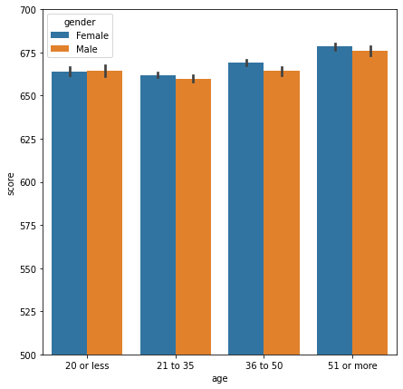

```python
fig, ax= plt.subplots(nrows=1, ncols=1, figsize=(7,7))
ax = sns.barplot(data=df, x="age", y="score", hue="gender", order=['20 or less', '21 to 35', '36 to 50', '51 or more'],)

ax.set(ylim=(500, 700))
plt.show()
```

For that we first used a barplot, grouped by age and gender.

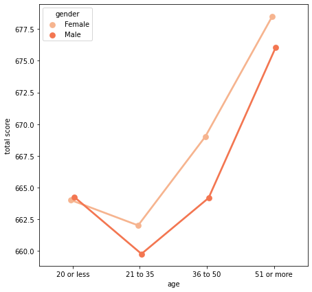

```python
totalScore_age_gender = df.groupby(['age','gender'], as_index=False)['score'].mean()
fig, ax= plt.subplots(nrows=1, ncols=1, figsize=(7,7))
ax = sns.pointplot(x='age', y='score',hue='gender', dodge=True, data=totalScore_age_gender, ci=68, ax=ax,palette=sns.color_palette("rocket_r"))
#ylimit (ylim...)

ax.set(ylabel='total score')

plt.show()
```

We used the pointplot afterwards, that makes it easier to spot differences between two (or more) groups, in this case male and female.

# **2. Income and stress level/time for hobbies**

In this section we wanted to see, if people with sufficient or hardly suffienct income showed differences in the stress level and time for hobbies. We assumed, that people with sufficient income showed less stress and more time for hobbies than people with hardly sufficient income.

```python
df_income = df
df_income.loc[:, "Income"] = df_income['sufficient_income'].replace({1:"Hardly sufficient",
                                     2:"Sufficient"})
```

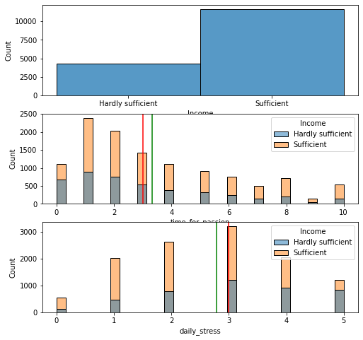

```python
fig, ax = plt.subplots(nrows=3, ncols=1,figsize=(8,8))
ax[0] = sns.histplot(data=df_income, x='Income', ax = ax[0])

ax[1] = sns.histplot(data=df_income, x='time_for_passion', ax = ax[1], hue = 'Income')
ax[2] = sns.histplot(data=df_income, x='daily_stress', ax = ax[2], hue = 'Income')

ax[1].axvline(df_income.time_for_passion.mean(), color='green')
ax[1].axvline(df_income.time_for_passion.median(), color='red')

ax[2].axvline(df_income.daily_stress.mean(), color='green')
ax[2].axvline(df_income.daily_stress.median(), color='red');
```

First we used histplots to show the distribution of sufficient and hardly sufficient income throughout the participants, as well as the distribution of the scores in the categories time for passion (hobbies) and daily stress.

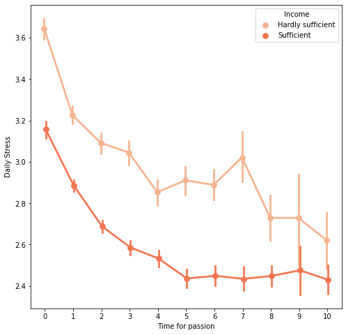

```python
fig, ax= plt.subplots(figsize=(8,8))
ax = sns.pointplot(x='time_for_passion', y='daily_stress',hue='Income', dodge=True, data=df_income, ci=68, ax=ax,palette=sns.color_palette("rocket_r"))

ax.set(ylabel='Daily Stress')
ax.set(xlabel = 'Time for passion')

plt.show()
```

We then used a pointplot to show the relation between time for passion and stress between the two groups.

# **3. Life Vision**

In this section, we will visualize how clearly participants of the survey of different age groups and genders could imagine their future (For how many years ahead is your life vision clear for you?). Our hypothesis is, that the older one gets, the clearer the life vision. We also assume, that men are more clear about what they wil be doing in the years ahead as they typically stay in their career path, while women might change their jobs or stop working completely after having children.

```
[Text(0, 0.5, 'Years of Life Vision'), Text(0.5, 0, 'Age')]
```

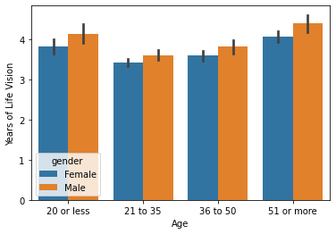

```python
# REPRESENTATION

ax = sns.barplot(x="age",y = "life_vision", hue = "gender", data=df, order=['20 or less', '21 to 35', '36 to 50', '51 or more'])
ax.set(ylabel='Years of Life Vision',xlabel='Age')
```

The plot clearly supports our suggestion, that men are clear about their life for a longer period of time. For us, although we did hypothesise about this, we are still surprised, that in our emancipated world, it is still the case that women are more unsure how the next years of their lifes will look like than men.

# **4. Longterm Wellbeing versus Instant Life Gratification**

Longterm Wellbeing includes life vision, achievements, awards and sufficient income. Instant Life Gratification includes good sleep, regular walking and other shortterm life pleasure, spending time with friends, time for oneself and meditation

```python
df["longterm_wellbeing"] = df[['life_vision','achievement','personal_awards','sufficient_income']].mean(axis = 1)
df["shortterm_wellbeing"] = df[['sleep_hours','fruits_veggies','places_visited','core_circle','social_network','time_for_passion','weekly_meditation']].mean(axis = 1)
df.head()
```

|  | timestamp | fruits_veggies | daily_stress | places_visited | core_circle | supporting_others | social_network | achievement | donation | bmi_range | todo_completed | flow | daily_steps | life_vision | sleep_hours | lost_vacation | daily_shouting | sufficient_income | personal_awards | time_for_passion | weekly_meditation | age | gender | score | longterm_wellbeing | shortterm_wellbeing |
| --- | --- | --- | --- | --- | --- | --- | --- | --- | --- | --- | --- | --- | --- | --- | --- | --- | --- | --- | --- | --- | --- | --- | --- | --- | --- | --- |
| 0 | 7/7/15 | 3 | 2.0 | 2 | 5 | 0 | 5 | 2 | 0 | 1 | 6 | 4 | 5 | 0 | 7 | 5 | 5 | 1 | 4 | 0 | 5 | 36 to 50 | Female | 609.5 | 1.75 | 3.857143 |
| 1 | 7/7/15 | 2 | 3.0 | 4 | 3 | 8 | 10 | 5 | 2 | 2 | 5 | 2 | 5 | 5 | 8 | 2 | 2 | 2 | 3 | 2 | 6 | 36 to 50 | Female | 655.6 | 3.75 | 5.000000 |
| 2 | 7/7/15 | 2 | 3.0 | 3 | 4 | 4 | 10 | 3 | 2 | 2 | 2 | 2 | 4 | 5 | 8 | 10 | 2 | 2 | 4 | 8 | 3 | 36 to 50 | Female | 631.6 | 3.50 | 5.428571 |
| 3 | 7/7/15 | 3 | 3.0 | 10 | 3 | 10 | 7 | 2 | 5 | 2 | 3 | 5 | 5 | 0 | 5 | 7 | 5 | 1 | 5 | 2 | 0 | 51 or more | Female | 622.7 | 2.00 | 4.285714 |
| 4 | 7/7/15 | 5 | 1.0 | 3 | 3 | 10 | 4 | 2 | 4 | 2 | 5 | 0 | 5 | 0 | 7 | 0 | 0 | 2 | 8 | 1 | 5 | 51 or more | Female | 663.9 | 3.00 | 4.000000 |

```
          age  gender  longterm_wellbeing
0  20 or less  Female            3.782629
1  20 or less    Male            3.677387
2    21 to 35  Female            3.624188
3    21 to 35    Male            3.558531
4    36 to 50  Female            3.813323
5    36 to 50    Male            3.963991
6  51 or more  Female            4.001746
7  51 or more    Male            4.298226
```

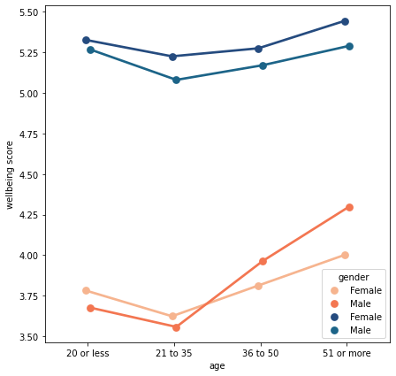

```python
#average wellbeing score per age group
longterm_age_gender = df.groupby(['age','gender'], as_index=False)['longterm_wellbeing'].mean()
shortterm_age_gender = df.groupby(['age','gender'], as_index=False)['shortterm_wellbeing'].mean()
print(longterm_age_gender)
# visualize average development of wellbeing over age between genders
#shortterm is blue, longterm is orange, needs label
fig, ax= plt.subplots(nrows=1, ncols=1, figsize=(7,7))

ax = sns.pointplot(
    x='age',
    y='longterm_wellbeing',
    hue='gender',
    dodge=True,
    data=longterm_age_gender,
    ci=68,
    ax=ax,palette=sns.color_palette("rocket_r"),
    label = "longterm wellbeing"
    )
ax = sns.pointplot(
    x='age',
    y='shortterm_wellbeing',
    hue='gender',
    dodge=True,
    data=shortterm_age_gender,
    ci=68,
    ax=ax,palette=sns.color_palette("crest_r"),
    label = "shortterm wellbeing"
    )

ax.set(ylabel='wellbeing score')

plt.show()
```

**Observations**: **Text fett markieren** -There seems to be a correlation between longterm and shortterm wellbeing from age 20 or less to 50

-Women seem to care more about their wellbeing in the 'now', as well as the continuancy of their wellbeing in younger years than men

-Men show a high interest in ensuring longterm wellbeing after the age of 35, likely because they usually earn more, achieve more...

-Generally, there is an upwards tendency in both shortterm and longterm wellbeing

-Somehow, between 21 and 35 years both scores are at there minimum

Arising Questions for further investigation:

1. Why do men have higher scores in longterm wellbeing? Hypothesis: Men have higher scores in achievement and earnings than women in the age groups older than 35.

```python
#values for age group 36 to 50
df_lv_36_50 = df[df["age"]=="36 to 50"].groupby(['gender'], as_index=False)['longterm_wellbeing'].mean()

values_female_1 = df_lv_36_50.loc[0, :].values.tolist()
values_male_1 = df_lv_36_50.loc[1, :].values.tolist()


# values for age group older than 51
df_lv_51 = df[df["age"]=="51 or more"].groupby(['gender'], as_index=False)['longterm_wellbeing'].mean()

values_female_2 = df_lv_51.loc[0, :].values.tolist()
values_male_2 = df_lv_51.loc[1, :].values.tolist()
```

```
(3.0, 7.0)
```

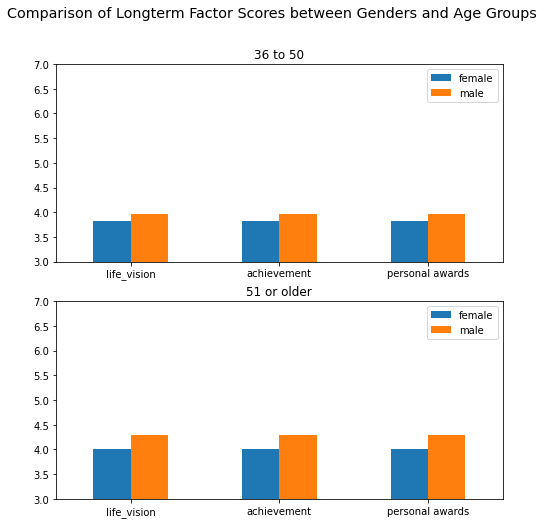

```python
df1 = pd.DataFrame({'female': values_female_1[1:4],'male': values_male_1[1:4]}, index=['life_vision','achievement', 'personal awards'])
df2 = pd.DataFrame({'female': values_female_2[1:4],'male': values_male_2[1:4]}, index=['life_vision','achievement', 'personal awards'])

#create figure and title
fig, axes = plt.subplots( nrows=2, ncols=1, figsize=(8,8),sharey=True)
fig.suptitle("Comparison of Longterm Factor Scores between Genders and Age Groups", fontsize="x-large")

#create subplots
df1.plot.bar(ax=axes[0],rot = 0, title = "36 to 50")
df2.plot.bar(ax=axes[1], rot = 0, title = "51 or older")
plt.ylim(3,7)
```

# **5. Donations and Helping Others**

1. Is it more common to donate or to help others elsewhere?

> Hypothesis: Motivation to donate increases with age, while helping others does not.
1. Do people with high motivation for helping others or donating higher scores in other aspects too and if so, which aspects particularly?

```
[Text(0, 0.5, 'Frequency of Helping Elsewhere'), Text(0.5, 0, 'Age')]
```

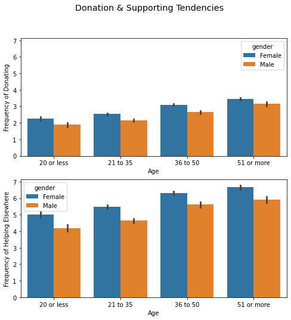

```python
#create figure and title
fig, ax = plt.subplots( nrows=2, ncols=1, figsize=(8,8),sharey=True)
fig.suptitle("Donation & Supporting Tendencies", fontsize="x-large")

# create subplots
ax[0] = sns.barplot(x="age",y = "donation", hue = "gender", data=df, order=['20 or less', '21 to 35', '36 to 50', '51 or more'],ax = ax[0])
ax[0].set(ylabel='Frequency of Donating',xlabel='Age')


ax[1] = sns.barplot(x="age",y = "supporting_others", hue = "gender", data=df, order=['20 or less', '21 to 35', '36 to 50', '51 or more'],ax = ax[1])
ax[1].set(ylabel='Frequency of Helping Elsewhere',xlabel='Age')
```

```python
#getting actual values
df.groupby(["gender","age"])["donation","supporting_others"].mean()
```

| gender | age | donation | supporting_others |
| --- | --- | --- | --- |
| Female | 20 or less | 2.253521 | 5.003756 |
|  | 21 to 35 | 2.538266 | 5.477266 |
|  | 36 to 50 | 3.101317 | 6.315772 |
|  | 51 or more | 3.449149 | 6.655609 |
| Male | 20 or less | 1.893899 | 4.194960 |
|  | 21 to 35 | 2.144137 | 4.631087 |
|  | 36 to 50 | 2.655254 | 5.609209 |
|  | 51 or more | 3.153776 | 5.896269 |

Observations concerning Question 1.:

- In general, the frequency of helping others is approx. twice as high as the frequency of donating money
- In all age groups, women are helping and donating more often than men.
- Our hypothesis is only partly correct, as the frquency of donating money increases with age, like we suggested, but the frequency of helping others does so as well

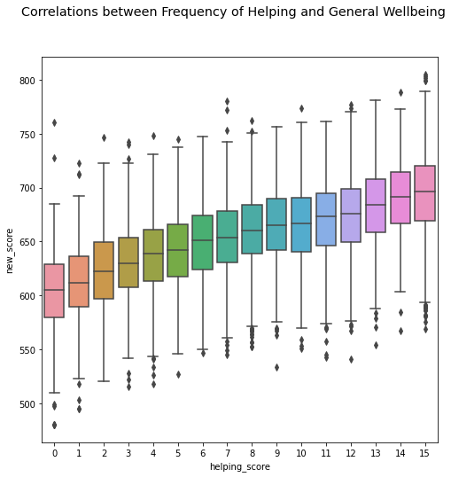

```python
#score of donation and supporting others sum
df['helping_score'] = df['donation']+df['supporting_others']

#score minus helping score
df['new_score'] = df['score']-df['helping_score']


#helping and general score boxplot

fig, ax = plt.subplots(nrows=1, ncols=1, figsize=(8,8))
fig.suptitle("Correlations between Frequency of Helping and General Wellbeing", fontsize="x-large")

sns.boxplot(data=df, x='helping_score', y='new_score', ax=ax)
```

This plot shows the sum of the frequencies of helping and donating on the x axis and the general wellbeing score with the freuwencies excluded. We can clearly see that the wellbeing increases with increasing motivation to help other people.

# **6. The 5 Pillars of a Good Lifestyle**

The Work-Life Balance survey evaluates how we thrive in both our professional and personal lives: it reflects how well we shape our lifestyle, habits and behaviors to maximize our overall life satisfaction along the following five dimensions:

1. **Healthy body**, reflecting fitness and healthy habits;
2. **Healthy mind**, indicating how well we embrace positive emotions;
3. **Expertise**, measuring the ability to grow expertise and achieve something unique;
4. **Connection**, assessing the strength of our social network and inclination to discover the world;
5. **Meaning**, evaluating our compassion, generosity and how much we are living the life of our dream.

In the following code blocks, we assigned the questions into the 5 different categories to see how well the subjects do in different pillars of their life and whether there are patterns across age or gender.

```python
#assign categories to pillars

#scores are the sum of the achieved points divided by the maximum of achievable points
body_score = df[['bmi_range','fruits_veggies','daily_steps','sleep_hours']].sum(axis = 1)/40
mind_score = ((30-df[['lost_vacation','daily_stress','daily_shouting']].sum(axis = 1)) + df[['time_for_passion','weekly_meditation']].sum(axis = 1))/50
expertise_score = df[['personal_awards','achievement','todo_completed','sufficient_income']].sum(axis = 1)/40
connection_score = df[['social_network','core_circle','places_visited']].sum(axis = 1)/30
meaning_score = df[['life_vision','donation','supporting_others','flow']].sum(axis = 1)/40
total_score = body_score + mind_score + expertise_score + connection_score + meaning_score
```

```python
#create dict with percentages of pillars
pillars = {'body': (body_score/total_score)*100,
        'mind' : (mind_score/total_score)*100,
        'expertise' : (expertise_score/total_score)*100,
        'connection' : (connection_score/total_score)*100,
        'meaning' : (meaning_score/total_score)*100
        }

# convert into dataframe
pillars_df = pd.DataFrame(pillars)

#add subject gender and age
pillars_df['age']=df['age']
pillars_df['gender']=df['gender']
pillars_df
```

|  | body | mind | expertise | connection | meaning | age | gender |
| --- | --- | --- | --- | --- | --- | --- | --- |
| 0 | 23.738872 | 27.299703 | 19.287834 | 23.738872 | 5.934718 | 36 to 50 | Female |
| 1 | 17.622668 | 25.708362 | 15.549413 | 23.496890 | 17.622668 | 36 to 50 | Female |
| 2 | 19.169329 | 24.920128 | 13.178914 | 27.156550 | 15.575080 | 36 to 50 | Female |
| 3 | 17.387944 | 15.765070 | 12.751159 | 30.911901 | 23.183926 | 51 or more | Female |
| 4 | 20.802920 | 30.656934 | 18.613139 | 14.598540 | 15.328467 | 51 or more | Female |
| ... | ... | ... | ... | ... | ... | ... | ... |
| 15967 | 23.387668 | 28.065202 | 14.883062 | 19.844082 | 13.819986 | 51 or more | Female |
| 15968 | 13.675214 | 27.350427 | 21.367521 | 20.512821 | 17.094017 | 21 to 35 | Female |
| 15969 | 14.705882 | 25.605536 | 21.626298 | 20.761246 | 17.301038 | 21 to 35 | Male |
| 15970 | 10.728218 | 26.527958 | 11.703511 | 32.509753 | 18.530559 | 21 to 35 | Female |
| 15971 | 17.429194 | 27.015251 | 16.339869 | 17.429194 | 21.786492 | 21 to 35 | Female |

15972 rows × 7 columns

Questions for Investigation:

1. To what degree do the pillars contribute to the general welbeing?
2. Are there gender/age differences?

```python
#pillar importancy grouped by gender
pie_data_gender = pillars_df.groupby(["gender"])["body","mind","expertise","connection", "meaning"].mean()
pie_data_gender = pie_data_gender.reset_index()


#pillar importancy grouped by age
pie_data_age = pillars_df.groupby(["age"])["body","mind","expertise","connection", "meaning"].mean()
pie_data_age = pie_data_age.reset_index()
```

[output not shown]

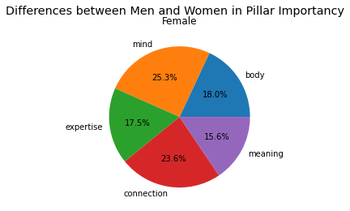

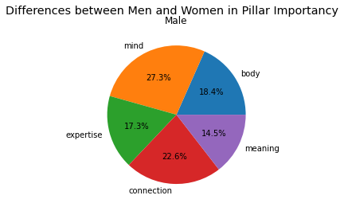

```python
#pie chart for gender differences
for i in pie_data_gender.index:
   fig, ax = plt.subplots(1,1)
   fig.suptitle("Differences between Men and Women in Pillar Importancy", fontsize="x-large")

   pie_data_gender[["body","mind","expertise","connection", "meaning"]].iloc[i].plot(kind='pie', ax=ax, autopct='%1.1f%%')

   #set title and remove labels
   ax.set_title(pie_data_gender['gender'].iloc[i])
   ax.set_ylabel('')
   ax.set_xlabel('')
```

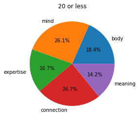

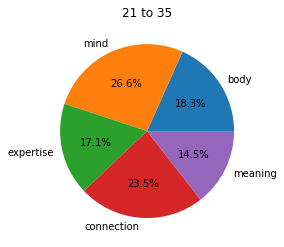

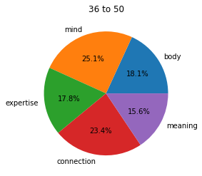

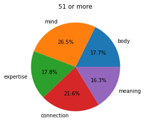

```python
#pie chart for age differences
for i in pie_data_age.index:
   fig, ax = plt.subplots(1,1)
   pie_data_age[["body","mind","expertise","connection", "meaning"]].iloc[i].plot(kind='pie', ax=ax, autopct='%1.1f%%')

   #set title and remove labels
   ax.set_title(pie_data_age['age'].iloc[i])
   ax.set_ylabel('')
   ax.set_xlabel('')
```

Observation:

- There seem to be no significant differences between genders or age groups overall
- We notice a small increase in the importance of meaning with age

# **7. Stress and Wellbeing**

From daily life struggles we know that Wellbeing and Stress mostly do not contribute. But is this really true? And if yes what does contribute most to Stress? In the Dataset Lifestyle and Wellbeing a lot of different Informations were gathered and we can now check if these Contributions are correct and also if there are any possibilities to reduce our daily stress.

**Is it true, that Stress and a Work-Life-Balance have a negative correlation?**

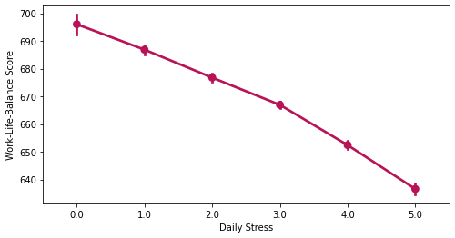

```python
# contribution of Stress and Work-Life-Balance

fig, ax= plt.subplots(nrows=1, ncols=1, figsize=(8,4))


ax = sns.pointplot(data=df, x='daily_stress', y='score',sort = True, color="#B91357")

ax.set(ylabel='Work-Life-Balance Score')
ax.set(xlabel='Daily Stress')

plt.show()
```

**Observation:**

Wellbeing and Daily Stress are correlating, but they have a negative correlation. From the Diagram we cannot tell if Daily Stress is affecting the the decrease of the Wellbeing Score, or if it the other way around. We can for sure say, that there is a Contribution between Stress and the Wellbeing Score.

**What contributes with the daily stress level, which does affect it positive and which affects the stress negative?**

Therefore the Correlation of Daily Shouting, Lost Vacations, Sleeping Hours, Hobbys, Meditation and Daily Stress will be shown. For this purpose the people were asked to rate how many days of vacation they typically lose every year, how often they shout or sulk at somebody and how long the typically sleep.

```
[Text(0, 0.5, 'Sleeping Hours'), Text(0.5, 0, 'Daily Stress')]
```

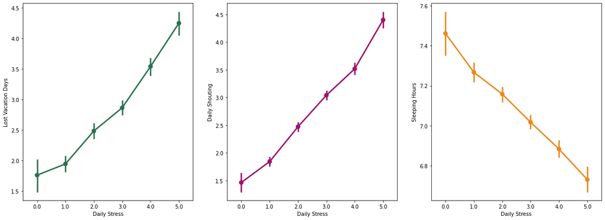

```python
# daily_shouting, lost_vacation, sleep_hours, time_for_passion, weekly_meditation, work_life_balance_score

fig, ax= plt.subplots(nrows=1, ncols=3, figsize=(20,7))


#HOW MANY DAYS OF VACATION DO YOU TYPICALLY LOSE EVERY YEAR ?
sns.pointplot(ax = ax[0],data=df, x="daily_stress", y="lost_vacation", color='#2C7051')

#HOW OFTEN DO YOU SHOUT OR SULK AT SOMEBODY?
sns.pointplot(ax = ax[1], data=df, x="daily_stress" , y="daily_shouting", color='#9C146B')

#ABOUT HOW LONG DO YOU TYPICALLY SLEEP?
sns.pointplot(ax = ax[2], data=df, x="daily_stress" , y="sleep_hours", color='#E88A1E')


ax[0].set(ylabel='Lost Vacation Days', xlabel='Daily Stress')

ax[1].set(ylabel='Daily Shouting', xlabel='Daily Stress')

ax[2].set(ylabel='Sleeping Hours', xlabel='Daily Stress')
```

**Observation:**

As we can see within these three Graphs, there is a huge Correlation between Lost Vacations Days, the Amount of Daily Shouting and the Sleeping Hours. Again we cannot say which causes which, but there is a definite contribution.

**Can Stress be reduced by Meditation, enough sleep or having time for your passions?**

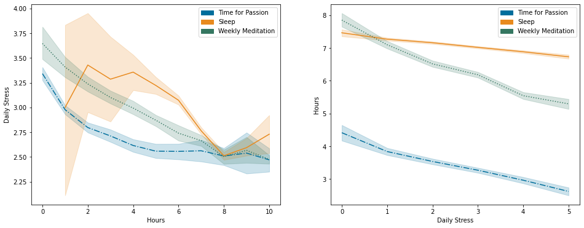

```python
#correlation between the sleeping_hours and the daily_stress,


sns.set_palette("Paired")

passion = mpatches.Patch(color='#006E9C', label='Time for Passion')
sleep = mpatches.Patch(color='#E88A1E', label='Sleep')
meditation = mpatches.Patch(color='#357761', label='Weekly Meditation')


fig, ax= plt.subplots(nrows=1, ncols=2, figsize=(16,6))


#sns.pointplot(ax = ax[0], data=df, x="daily_stress", y="time_for_passion", color='purple')

#sns.pointplot(ax = ax[0],data=df, x="daily_stress", y="sleep_hours", color="darkblue")

#sns.pointplot(ax = ax[0],data=df, x="daily_stress", y="weekly_meditation", color='green')


#lineplots X= Hours, Y= Daily Stress
sns.lineplot(ax= ax[0], data=df, x="time_for_passion" , y="daily_stress",color='#006E9C', linestyle='dashdot')

sns.lineplot(ax= ax[0], data=df, x="sleep_hours", y="daily_stress",color='#E88A1E', linestyle='solid')

sns.lineplot(ax= ax[0],data=df, x="weekly_meditation", y="daily_stress",color='#357761', linestyle='dotted')

#lineplots X= Daily Stress, Y= Hours
sns.lineplot(ax= ax[1], data=df,x="daily_stress", y="time_for_passion", color='#006E9C', linestyle='dashdot')

sns.lineplot(ax= ax[1], data=df,x="daily_stress", y="sleep_hours", color='#E88A1E', linestyle='solid')

sns.lineplot(ax= ax[1],data=df, x="daily_stress", y="weekly_meditation", color='#357761', linestyle='dotted')


#ax[0].legend(handles=[passion, sleep, meditation])
#ax[0].set(xlabel="Daily Stress", ylabel="Hours")

ax[0].legend(handles=[passion, sleep, meditation])
ax[0].set(xlabel="Hours", ylabel="Daily Stress")

ax[1].legend(handles=[passion, sleep, meditation])
ax[1].set(xlabel="Daily Stress", ylabel="Hours")

plt.show()
```

**Observations:**

The Question was how Daily Stress and the Amount of Sleep, Meditation and Hobbies contradict themselves. To answer this Question from both sides, we made two plots in the left Graph we will observe the how the Increase of Sleep, Time for Passion and weekly Meditatin affects on the Daily Stress. In the right Graph we will observe how the Increase of Daily Stress has an affect on Time for Sleep, Passion and Meditation. Therefore we switched the x- and y-axis of the Graphs.

On the left Graph, we can see that the range between people having about 1 hour of sleep per night and having a lot of stress and not a lot of stress differs widely. Also the with the Increase of Sleep, Meditation and Time for Passion/Hobbies the Stress Level decreases. Whereas on the right Graph it looks as the increase of Daily Stress contradicts the decrease of especially Meditation and Time for Passion and the Amount of Sleeps remains nearly the same. Still we cannot say which contradicts each other more, but we can tell that there is a Correlation between the Time for Mediation and Passion and the Daily Stress Level.

# **8. General Correlations**

Since we are coming to an end of this notebook, let's have a last look at all the Contributions between all the attributes from the dataset. Therefore we will use a Heatmap where we can see if there is a positive correlation (red) or a negative correlation (blue), or no found correlation (white) between the attributes.

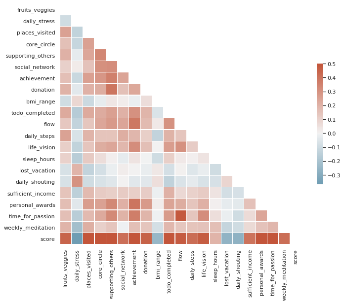

```python
sns.set_theme(style="white")


corr = df.corr()

mask = np.triu(np.ones_like(corr, dtype=bool))

# Set up the matplotlib figure
f, ax = plt.subplots(figsize=(11, 9))

# Generate a custom diverging colormap
cmap = sns.diverging_palette(230, 20, as_cmap=True)

# Draw the heatmap with the mask and correct aspect ratio
sns.heatmap(corr, mask=mask, cmap=cmap, vmax=.5, center=0,
            square=True, linewidths=.2, cbar_kws={"shrink": .5}, linecolor='white')
```

**Observations:**

Within the Heatmap we can see strong Correlations between different attributes. We can see that there are some attribues contributing with the Work-Life Balance Score, as we predicted before (e.g. daily stress, lost vacation and daily shouting, whereas we did not have a look at the bmi-range. Also we can see all the positive correlations with the score as e.g. places visited, flow, personal awards etc. Suprisingly we can see that there is a positive correlation between having time for passion and having a flow.